# Bioestadística, Zootecnia

Tasas, razones, proporciones y tendencia central

Departamento de Estadı́stica, Sede Bogotá

## Clase 3

Tasas, Razones, Proporciones

y Medidas de Tendencia Central

Herramientas esenciales para resumir y comparar datos

Bioestadística Fundamental, Departamento de Estadística, UNAL Bogotá

## Contenido

### Parte I: Comparación de cantidades

- Tasas: relacionar magnitudes con unidades distintas.
- Razones: comparar dos cantidades de la misma clase.
- Proporciones: igualdad entre razones.
- Proporción estadística y porcentaje.

### Parte II: Medidas de tendencia central

- Media aritmética: el promedio.
- Mediana: el valor central.
- Moda: el valor más frecuente.
- ¿Cuándo usar cada medida?

## Parte I

Tasas, Razones y Proporciones

Herramientas para comparar e interpretar cantidades

## ¿Por qué necesitamos estas herramientas?

- En zootecnia, salud animal, economía e ingeniería es fundamental **comparar cantidades e interpretar datos** para tomar decisiones acertadas.
- Las matemáticas proveen tres herramientas clave para este propósito: **tasas**, **razones** y **proporciones**.
- Situaciones cotidianas que requieren estas herramientas:
- Determinar la ganancia diaria de peso por animal.
- Evaluar la tasa de incidencia de una enfermedad en un hato.
- Calcular cuánto alimento se necesita al aumentar el número de animales.
- Comparar la productividad entre dos explotaciones pecuarias de distinto tamaño.

## Tasas: Definición

Definición: Tasa

Una **tasa** es una razón que compara dos cantidades con *unidades de medida diferentes*. Expresa cuántas unidades de la primera magnitud corresponden a una unidad de la segunda.
$$\text{Tasa} = \frac{\text{cantidad}_A \text{ [unidad}_A\text{]}}{\text{cantidad}_B \text{ [unidad}_B\text{]}}$$

- Las unidades de la tasa resultan de combinar las unidades de ambas magnitudes: km/h, kg/ha, casos/100 000 hab.
- Las tasas permiten **comparar en igualdad de condiciones** situaciones que tienen distinto tamaño o duración.

## Tasas: Características y usos

Características

- Relacionan **magnitudes con unidades distintas**.
- Se expresan con unidades compuestas (km/h, mg/L, kg/ha).
- Permiten medir **velocidad, rendimiento y densidad**.
- Son la base de los indicadores estadísticos.

Aplicaciones

- **Zootecnia:** ganancia de peso (kg/animal/día), consumo de agua (L/animal/día).
- **Salud animal:** incidencia (casos/100 000 animales), mortalidad (muertes/1 000 animales).
- **Producción animal:** leche (L/vaca/día), alimento (kg/lote/día).

## Tasas: ejemplos

Ejemplo 1: Consumo de agua

Un grupo de animales consume 120 L de agua en 2 horas. ¿Cuál es la tasa de consumo?
$$\text{Tasa} = \frac{120\,\text{L}}{2\,\text{h}} = 60\,\text{L/h}$$
Interpretación: el grupo consume **60 L de agua por cada hora**.

Ejemplo 2: Producción de leche

En un mes, 4 vacas producen 800 L de leche. ¿Cuál es la producción mensual por vaca?
$$\text{Tasa} = \frac{800\,\text{L}}{4\,\text{vacas}} = 200\,\text{L/vaca}$$
Interpretación: se producen **200 L de leche por vaca durante el mes**.

## Tasas en salud animal

Tasas epidemiológicas veterinarias

En epidemiología, las tasas miden la frecuencia de eventos de salud en una población animal:
$$\text{Tasa de incidencia} = \frac{\text{casos nuevos en un período}}{\text{animales en riesgo}} \times 100\,000$$

Ejemplo: enfermedad respiratoria en aves

En una población de 50 000 aves se registraron 75 casos nuevos de enfermedad respiratoria en un mes.
$$\text{Tasa de incidencia} = \frac{75}{50\,000} \times 100\,000 = 150\text{ casos por cada 100 000 aves}$$

## Ejercicios: Tasas

Ejercicios

Calcule e interprete cada tasa:

1. Un lote consume 400 kg de alimento en 8 días. ¿Cuál es el consumo diario?
2. En una granja se distribuyen 250 kg de suplemento en 5 lotes. ¿Cuánto se usa por lote?
3. En una granja con 2 000 aves se reportaron 12 casos de enfermedad en un mes. ¿Cuál es la tasa de incidencia por 1 000 aves?

Soluciones

1. $400\,\text{kg} / 8\,\text{días} = \mathbf{50\,\text{kg/día}}$.
2. $250\,\text{kg} / 5\,\text{lotes} = \mathbf{50\,\text{kg/lote}}$.
3. $(12 / 2\,000) \times 1\,000 = \mathbf{6\text{ casos por cada 1 000 aves}}$.

## Razones: Definición

Definición: Razón

Una **razón** es una relación matemática que compara dos cantidades **de la misma clase** mediante una división, expresando cuántas veces una cantidad está contenida en la otra.
$$\text{Razón} = \frac{a}{b} = a : b \quad (b \neq 0)$$

- A diferencia de la tasa, en una razón ambas cantidades tienen las **mismas unidades**, las cuales se cancelan y el resultado es adimensional.
- Se puede leer como *“a por cada b”* o *“a es a b”*.

## Razones: Ejemplos resueltos

Ejemplo 1: Composición de un hato

En un hato hay 60 vacas adultas y 30 terneros.
$$\text{Razón} = \frac{60}{30} = 2 \quad \Leftrightarrow \quad 2:1$$
Interpretación: hay **2 vacas adultas por cada 1 ternero**.

Ejemplo 2: Sexo en un hato

En un hato de 60 animales, 40 son hembras y 20 son machos.
$$\text{Razón hembras:machos} = \frac{40}{20} = 2 \quad \Leftrightarrow \quad 2:1$$
Interpretación: hay **2 hembras por cada macho** en el grupo.

## Ejercicios: Razones

Ejercicios

Calcule e interprete cada razón:

1. En un hato hay 90 vacas y 30 toros.
2. Se distribuyen 80 kg de suplemento entre 40 comederos. ¿Cuántos kg hay por comedero?
3. En un lote hay 60 animales, 20 de ellos son machos. ¿Cuál es la razón machos:hembras?

Soluciones

1. $90/30 = 3:1$, hay 3 vacas por cada toro.
2. $80/40 = 2$, hay 2 kg de suplemento por comedero.
3. Machos: 20, Hembras: 40. Razón $= 20/40 = 1:2$, hay 1 macho por cada 2 hembras.

## Proporciones: Definición

Definición: Proporción

Una **proporción** es una *igualdad entre dos razones*:
$$\frac{a}{b} = \frac{c}{d} \quad \Leftrightarrow \quad a \cdot d = b \cdot c$$
La segunda igualdad se denomina **propiedad de los productos cruzados** y es la clave para encontrar valores desconocidos.

- Las proporciones se usan para **escalar cantidades** manteniendo una relación constante.
- Son fundamentales en agronomía (ajustar dosis), nutrición (escalar recetas) y planificación (distribuir recursos).

## Proporciones: Ejemplo 1

Problema, suplemento y animales

En una granja, 4 kg de suplemento son suficientes para 8 animales. ¿Cuántos kg se necesitan para 20 animales, manteniendo la misma proporción?

Solución

Planteamiento:
$$\frac{4\,\text{kg}}{8\,\text{animales}} = \frac{x}{20\,\text{animales}}$$
Productos cruzados:
$$4 \times 20 = 8x \implies 80 = 8x \implies x = 10\,\text{kg}$$
Se necesitan **10 kg de suplemento** para 20 animales.

## Proporciones: Ejemplo 2

Problema, animales que alcanzan la meta

En un lote, 15 de cada 30 terneros alcanzan la meta de peso. Si se mantiene la misma proporción, ¿cuántos la alcanzarían en un lote de 80?

Solución

$$\frac{15}{30} = \frac{x}{80}$$
$$15 \times 80 = 30x \implies 1\,200 = 30x \implies x = 40\,\text{terneros}$$
Alcanzarían la meta **40 terneros**. La razón de cumplimiento es constante: $1/2$.

## Ejercicios: Proporciones

Ejercicios, Halle el valor de $x$

1. $$3\,\text{kg} \longrightarrow 9\,\text{animales}, \quad x \longrightarrow 18\,\text{animales}$$
2. $$5\,\text{L} \longrightarrow 10\,\text{corrales}, \quad x \longrightarrow 20\,\text{corrales}$$
3. En un lote de 200 aves, 30 presentan una enfermedad. ¿Cuántas aves enfermas se esperan en un lote de 500?

Soluciones

1. $\frac{3}{9} = \frac{x}{18} \implies x = 6\,\text{kg}$.
2. $\frac{5}{10} = \frac{x}{20} \implies x = 10\,\text{L}$.
3. $\frac{30}{200} = \frac{x}{500} \implies x = 75\,\text{aves enfermas}$.

## Proporción estadística y porcentaje

Proporción estadística

En estadística, la proporción de una categoría es:
$$p = \frac{f_i}{n}$$
donde $f_i$ es la frecuencia de esa categoría y $n$ el total. Toma valores en $[0, 1]$.

Porcentaje

El porcentaje es la proporción expresada en base 100:
$$\% = p \times 100 = \frac{f_i}{n} \times 100$$
Toma valores en $[0\%, 100\%]$ y es más fácil de comunicar.

## Ejemplos: proporción y porcentaje

Ejemplo 1: animales con ganancia esperada

De 30 animales, 18 alcanzaron la ganancia de peso esperada.
$$p = \frac{18}{30} = 0{,}60 \qquad \% = 0{,}60 \times 100 = 60\%$$
El **60 %** de los animales alcanzó la ganancia esperada.

Ejemplo 2: animales sanos

En un hato se inspeccionan 50 animales, 20 resultan sanos.
$$p = \frac{20}{50} = 0{,}40 \qquad \% = 40\%$$
El **40 %** de los animales se encontró en buen estado de salud.

## Tabla comparativa: tasa, razón y proporción

[output not shown]

Las **tasas** responden a “¿cuánto X por unidad de Y?”; las **razones** responden a “¿cuántas veces?”; las **proporciones** responden a “¿qué parte del total?”

## Parte II

Medidas de Tendencia Central

Media, mediana y moda

## ¿Qué son las medidas de tendencia central?

- Las **medidas de tendencia central** son valores numéricos que representan el centro o valor típico de un conjunto de datos.
- Permiten resumir grandes volúmenes de datos en un solo número representativo, facilitando la comparación entre grupos.
- Las tres principales son:
- **Media aritmética ($\bar{x}$):** promedio de todos los datos.
- **Mediana ($Me$):** valor que ocupa la posición central.
- **Moda ($Mo$):** valor que se repite con mayor frecuencia.

## Media aritmética

Definición: Media aritmética

La **media aritmética** $\bar{x}$ es el cociente entre la suma de todos los valores y el número total de observaciones. Representa el **punto de equilibrio** de los datos.

Propiedades

- **Única:** para un conjunto de datos existe una sola media.
- **Usa todos los datos:** considera cada observación.
- **Sensible a valores extremos:** se ve afectada por datos atípicos.
- **Algebraica:** $\sum_{i=1}^n (x_i - \bar{x}) = 0$ (suma de desviaciones = 0).

## Media: fórmulas

Datos sin agrupar

$$\bar{x} = \frac{\displaystyle\sum_{i=1}^{n} x_i}{n} = \frac{x_1 + x_2 + \cdots + x_n}{n}$$
Donde $x_i$ son las observaciones y $n$ el número total de datos.

Datos agrupados

$$\bar{x} = \frac{\displaystyle\sum_{i=1}^{k} f_i x_i}{\displaystyle\sum_{i=1}^{k} f_i} = \frac{\displaystyle\sum_{i=1}^{k} f_i x_i}{n}$$
Donde $f_i$ es la frecuencia absoluta y $x_i$ el valor o marca de clase del $i$-ésimo grupo.

## Ejemplo 1: datos sin agrupar

Problema, producción de leche

Se registró la producción diaria de leche (L) de 15 vacas:

`18, 20, 19, 19, 21, 22, 20, 23, 21, 24, 19, 20, 22, 21, 24`

Calcule la producción diaria promedio.

Solución

Con $n = 15$:
$$\bar{x} = \frac{18 + 20 + 19 + \cdots + 21 + 24}{15} = \frac{313}{15} \approx 20{,}87\,\text{L}$$
La producción promedio es aproximadamente **21 L por vaca y día**.

## Ejemplo 2: datos agrupados sin intervalos

Se registró el consumo diario de alimento de 50 animales. Los resultados se agruparon así:

| $x_i$ (kg) | $f_i$ | $f_i x_i$ |
| --- | --- | --- |
| 4 | 2 | 8 |
| 5 | 5 | 25 |
| 6 | 7 | 42 |
| 7 | 12 | 84 |
| 8 | 14 | 112 |
| 9 | 7 | 63 |
| 10 | 3 | 30 |
| Total | 50 | 364 |

Solución

Con $k = 7$, $n = 50$ y $\sum f_i x_i = 364$:
$$\bar{x} = \frac{364}{50} = 7{,}28\,\text{kg}$$
En promedio, cada animal consume aproximadamente **7,28 kg de alimento** por día.

## Ejemplo 3: datos con intervalos

Se registró el peso (kg) de 20 animales en intervalos:

| Intervalo (kg) | $x_i$ (marca) | $f_i$ | $f_i x_i$ |
| --- | --- | --- | --- |
| 50 – 60 | 55 | 4 | 220 |
| 60 – 70 | 65 | 6 | 390 |
| 70 – 80 | 75 | 5 | 375 |
| 80 – 90 | 85 | 3 | 255 |
| 90 – 100 | 95 | 2 | 190 |
| Total | , | 20 | 1 430 |

Solución

La marca de clase es el punto medio de cada intervalo: $x_i = (L_{inf} + L_{sup})/2$.
$$\bar{x} = \frac{\sum f_i x_i}{n} = \frac{1\,430}{20} = 71{,}5\,\text{kg}$$
El peso promedio de los animales es **71,5 kg**.

## Media en R

```r
# Ejemplo 1: datos sin agrupar
leche <- c(18,20,19,19,21,22,20,23,21,24,19,20,22,21,24)
mean(leche)
```

```
[1] 20.86667
```

```r
# Ejemplo 2: datos agrupados (media ponderada)
xi <- c(4, 5, 6, 7, 8, 9, 10)
fi <- c(2, 5, 7,12,14, 7,  3)
sum(fi * xi) / sum(fi)
```

```
[1] 7.28
```

```r
# Ejemplo 3: datos con intervalos
xi_int <- c(55, 65, 75, 85, 95)
fi_int <- c(4, 6, 5, 3, 2)
sum(fi_int * xi_int) / sum(fi_int)
```

```
[1] 71.5
```

## Mediana

Definición: Mediana

La **mediana** ($Me$) es el valor que ocupa la posición central cuando los datos se **ordenan de menor a mayor**, dividiendo el conjunto en dos mitades iguales: 50 % de los valores queda por debajo y 50 % por encima.

Propiedades

- **Posicional:** depende del orden, no de la magnitud de los datos.
- **Robusta:** no se afecta por valores extremos (atípicos).
- **Única** (aunque puede requerir promediar dos valores centrales).
- **Preferida** cuando la distribución es asimétrica.

## Fórmulas para datos sin agrupar

$n$ impar

Hay un valor exactamente en el centro:
$$Me = x_{\left(\frac{n+1}{2}\right)}$$
Se toma el dato ubicado en la posición $\frac{n+1}{2}$ de la serie ordenada.

$n$ par

Hay dos valores centrales que se promedian:
$$Me = \frac{x_{\left(\frac{n}{2}\right)} + x_{\left(\frac{n}{2}+1\right)}}{2}$$
Se promedian los datos en las posiciones $\frac{n}{2}$ y $\frac{n}{2}+1$.

**Paso previo indispensable:** ordenar los datos de menor a mayor.

## Ejemplo 1: $n$ impar, sin agrupar

Producción diaria de leche de 13 vacas

Datos: 4, 6, 5, 7, 3, 8, 6, 5, 9, 7, 4, 6, 10. Calcule la mediana.

Solución

Datos ordenados: 3, 4, 4, 5, 5, 6, **6**, 6, 7, 7, 8, 9, 10. Con $n=13$ (impar):
$$Me = x_{\left(\frac{13+1}{2}\right)} = x_{(7)} = 6\,\text{L}$$
El 50 % de las vacas produce **6 L o menos**, y el otro 50 % produce 6 L o más.

## Ejemplo 2: $n$ par, sin agrupar

Ganancia mensual de peso de 14 terneros (kg)

Datos: 12, 15, 18, 20, 14, 16, 19, 17, 13, 21, 22, 11, 23, 24. Calcule la mediana.

Solución

Datos ordenados: 11, 12, 13, 14, 15, 16, **17**, **18**, 19, 20, 21, 22, 23, 24. Con $n=14$ (par):
$$Me = \frac{x_{(7)} + x_{(8)}}{2} = \frac{17 + 18}{2} = 17{,}5\,\text{kg}$$
La mitad de los terneros gana **17,5 kg o menos** y la otra mitad gana 17,5 kg o más.

## Datos agrupados sin intervalos

Procedimiento:

- Calcule $\frac{N+1}{2}$ (si $N$ es impar) o $\frac{N}{2}$ y $\frac{N}{2}+1$ (si $N$ es par).
- Busque esa(s) posición(es) en la columna de frecuencias acumuladas $F_i$.
- El valor $x_i$ que corresponde a la $F_i$ donde se alcanza o supera la posición buscada es la mediana.
- Si los dos valores centrales (caso par) caen en la misma $F_i$, no se promedia: ese $x_i$ es la mediana.

Ejemplo: crías por hembra ($N=13$, impar)

| $x_i$ | $f_i$ | $F_i$ |
| --- | --- | --- |
| 2 | 2 | 2 |
| 3 | 3 | 5 |
| 4 | 4 | 9 |
| 5 | 2 | 11 |
| 6 | 1 | 12 |
| 7 | 1 | 13 |

$\frac{13+1}{2}=7$; la posición 7 cae en $F_i=9$, que corresponde a $x_i=4$. **$Me = 4$ crías.**

## Datos agrupados con intervalos

Fórmula de la mediana interpolada

$$Me = L_i + \left(\frac{\dfrac{N}{2} - F_{i-1}}{f_i}\right) \cdot A$$
Donde: $L_i$ = límite inferior del intervalo mediano; $F_{i-1}$ = frecuencia acumulada anterior; $f_i$ = frecuencia absoluta del intervalo; $A$ = amplitud del intervalo.

- El **intervalo mediano** es aquel donde la frecuencia acumulada $F_i$ alcanza o supera $N/2$ por primera vez.

## Mediana con intervalos

Tiempo (min) requerido para el ordeño de un animal ($N=30$):

| Intervalo | $f_i$ | $F_i$ |
| --- | --- | --- |
| 0 – 10 | 3 | 3 |
| 10 – 20 | 5 | 8 |
| 20 – 30 | 9 | 17 |
| 30 – 40 | 7 | 24 |
| 40 – 50 | 6 | 30 |

$N/2 = 15$. La posición 15 cae en el intervalo **[20 – 30]** (donde $F_i=17$).

Solución

$L_i = 20$, $F_{i-1} = 8$, $f_i = 9$, $A = 10$:
$$Me = 20 + \left(\frac{15 - 8}{9}\right) \times 10 = 20 + 7{,}78 \approx 27{,}8\,\text{min}$$
La mitad de los animales completa el ordeño en **menos de 27 minutos y 47 segundos**.

## Mediana en R

```r
# Ejemplo 1: n impar
leche <- c(4, 6, 5, 7, 3, 8, 6, 5, 9, 7, 4, 6, 10)
sort(leche)
```

```
 [1]  3  4  4  5  5  6  6  6  7  7  8  9 10
```

```r
median(leche)
```

```
[1] 6
```

```r
# Ejemplo 2: n par
ganancia <- c(12,15,18,20,14,16,19,17,13,21,22,11,23,24)
median(ganancia)
```

```
[1] 17.5
```

## Moda

Definición: Moda

La **moda** ($Mo$) es el valor o categoría que aparece con **mayor frecuencia** en un conjunto de datos. Puede haber una sola moda (unimodal), dos (bimodal), varias (multimodal) o ninguna.

Propiedades

- **No única:** puede haber varias modas o ninguna.
- **No usa toda la información:** solo depende de la frecuencia.
- **Robusta ante atípicos:** no se ve afectada por valores extremos.
- **Aplica a variables cualitativas:** es la única medida válida para datos categóricos.

## Fórmulas

Sin agrupar / agrupados sin intervalos

La moda es el dato o categoría con la **mayor frecuencia absoluta**. No requiere fórmula; basta con identificar el valor más repetido.

Agrupados con intervalos (Czuber)

$$Mo = L_i + \left(\frac{f_i - f_{i-1}}{(f_i - f_{i-1}) + (f_i - f_{i+1})}\right) \cdot A$$
Donde $L_i$ es el límite inferior del intervalo modal, $f_{i-1}$ y $f_{i+1}$ las frecuencias adyacentes, y $A$ la amplitud.

## Ejemplo 1: datos sin agrupar

Producción diaria de leche de 15 vacas

Datos: 18, 20, 22, 20, 19, 21, 20, 22, 23, 20, 24, 21, 25, 27, 20

Solución

Datos ordenados: 18, 19, **20, 20, 20, 20, 20**, 21, 21, 22, 22, 23, 24, 25, 27.

El valor 20 aparece **5 veces**, es el de mayor frecuencia.
$$Mo = 20\,\text{L}$$
La producción de leche más frecuente es 20 L por vaca y día.

## Ejemplo 2: datos agrupados sin intervalos

Número de controles sanitarios realizados a 16 animales:

| $x_i$ | $f_i$ |
| --- | --- |
| 1 | 2 |
| 2 | 4 |
| 3 | 6 |
| 4 | 3 |
| 5 | 1 |
| Total | 16 |

Solución

La mayor frecuencia absoluta es $f = 6$, que corresponde a $x_i = 3$ trabajos.
$$Mo = 3\,\text{trabajos}$$
Los animales reciben, con mayor frecuencia, **3 controles**.

## Ejemplo 3 datos con intervalos

Consumo semanal de alimento (kg) de 35 animales:

| Consumo (kg) | $f_i$ |
| --- | --- |
| 0 – 20 | 4 |
| 20 – 40 | 6 |
| 40 – 60 | 12 |
| 60 – 80 | 8 |
| 80 – 100 | 5 |

Intervalo modal: **[40 – 60]** (mayor frecuencia: 12).

Solución

$L_i=40$, $f_i=12$, $f_{i-1}=6$, $f_{i+1}=8$, $A=20$:
$$Mo = 40 + \frac{12-6}{(12-6)+(12-8)} \times 20 = 40 + \frac{6}{10} \times 20 = 52$$
El consumo más frecuente es aproximadamente **52 kg semanales**.

## Moda en R

```r
# R no tiene función nativa para la moda; se calcula así:
leche <- c(18,20,22,20,19,21,20,22,23,20,24,21,25,27,20)
tabla  <- table(leche)
tabla
```

```
leche
18 19 20 21 22 23 24 25 27
 1  1  5  2  2  1  1  1  1
```

```r
# Valor con mayor frecuencia:
names(tabla)[which.max(tabla)]
```

```
[1] "20"
```

## ¿Cuándo usar cada medida?

| Medida | Mejor cuando… | Evitar cuando… |
| --- | --- | --- |
| **Media** | Distribución simétrica, sin valores atípicos. | Hay valores extremos que distorsionan el promedio. |
| **Mediana** | Distribución asimétrica o con atípicos. | Se necesita una medida algebraicamente tratable. |
| **Moda** | Datos cualitativos o cuando interesa el valor más típico. | Los datos tienen pocas repeticiones (puede ser poco informativa). |

En una distribución **simétrica** (como la normal): media = mediana = moda. Cuando hay **sesgo positivo**: media > mediana > moda. Cuando hay **sesgo negativo**: media < mediana < moda.

## Efecto de los valores atípicos

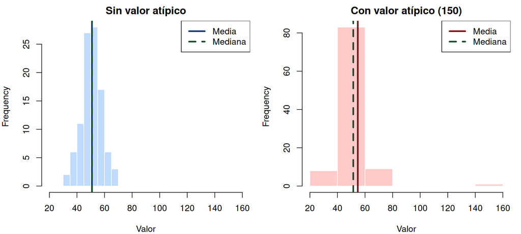

Un solo valor atípico puede desplazar significativamente la media, mientras la mediana permanece casi estable.

## Comparación de las tres medidas en R

```r
datos <- c(12,15,18,20,14,16,19,17,13,21,22,11,23,24,16,16)
cat("Media   :", round(mean(datos), 2), "\n")
```

```
Media   : 17.31
```

```r
cat("Mediana :", median(datos), "\n")
```

```
Mediana : 16.5
```

```r
tabla_moda <- table(datos)
cat("Moda    :", names(tabla_moda)[which.max(tabla_moda)], "\n")
```

```
Moda    : 16
```

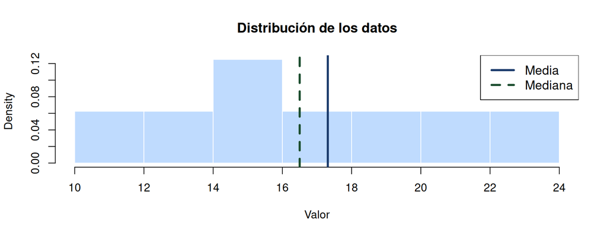

## Resumen de la clase

Parte I

- **Tasa:** razón entre magnitudes con unidades distintas (kg/ha, km/h).
- **Razón:** comparación adimensional entre cantidades de la misma clase.
- **Proporción:** igualdad entre dos razones; permite encontrar valores desconocidos con productos cruzados.
- **Porcentaje:** proporción estadística en base 100.

Parte II

- **Media $\bar{x}$:** promedio; sensible a atípicos.
- **Mediana $Me$:** valor central; robusta ante atípicos.
- **Moda $Mo$:** valor más frecuente; única medida para datos cualitativos.
- En distribuciones simétricas: $\bar{x} = Me = Mo$.

## Taller en clase

Ejercicios para resolver en clase

Tasas, razones, proporciones y medidas de tendencia central

## Ejercicio: producción porcina

Situación

En una granja porcina se recolectó información productiva durante un período de seguimiento.

- En 7 corrales se obtuvo una **ganancia total de 1 260 kg de peso vivo** en **9 días**.
- En la granja hay **420 cerdos en finalización** y **140 cerdos jóvenes**.
- De **280 cerdos** revisados, **196 estaban sanos** y **84 presentaban lesiones leves**.

Además, se seleccionaron 20 cerdos y se registró su **ganancia diaria de peso en gramos**:

`410, 425, 438, 442, 447, 452, 455, 458, 460, 462, 465, 468, 470, 472, 475, 478, 480, 485, 490, 498`

1. Calcule una **tasa** de ganancia de peso en kg/corral y una tasa en kg/día.
2. Calcule la **razón** entre cerdos en finalización y cerdos jóvenes.
3. Calcule la **proporción** de cerdos sanos y exprésela también en porcentaje.
4. Construya una **tabla de frecuencias agrupada** para el ganancia diaria de peso.
5. A partir de esa tabla, calcule la **media, mediana y moda** para datos agrupados.
6. Interprete cuál es el ganancia diaria típica de peso en esta muestra.